# Covid

## Base de datos:

- Plataforma Nacional de Datos Abiertos. (2020). Casos positivos por COVID-19 - [Ministerio de Salud - MINSA]. Recuperado el 4 de Junio, de MINSA Sitio web: https://www.datosabiertos.gob.pe/dataset/casos-positivos-por-covid-19-ministerio-de-salud-minsa
- Google LLC. (2020). Google COVID-19 Community Mobility Reports Peru.. Recuperado el 7 de mayo de 2020, de Google LLC Sitio Web: https://www.gstatic.com/covid19/mobility/2020-04-11_PE_Mobility_Report_en.pdf

## Descriptores numéricos para cada variable

- Frecuencia de salida de las personas (antes y después): Utilizamos mediana y media
- Cantidad de infectados por dia: Para relacionar esta data con las medidas utilizaremos la media, máximos y mínimos
- Edad: Para esta variable utilizamos la mediana para relacionar las respuestas brindadas por las personas en las encuestas con sus edades.

## Descriptores Gráficos

Utilizaremos:

- Gráfica de dispersión para notar fácilmente como aumenta o decrece la cantidad de infectados e infectados por dia antes y después de que se aplique la medida.
- Además, la gráfica de dispersión nos puede ayudar a encontrar una relación y/o patrón entre la cantidad de infectados y/o movilización social y los días transcurridos desde que se empleó cada medida.

## Gráficos:

### Librerías:

```r
library(curl)
library(tidyverse)
library(berryFunctions)
```

### Datos

### Casos de Covid en el Perú:

```r
tmp <- tempfile()
curl_download("https://cloud.minsa.gob.pe/s/Y8w3wHsEdYQSZRp/download", tmp)

readLines(tmp) %>%
    iconv(from = "ISO-8859-1", to = "UTF-8") %>%
    read_csv() %>%
    mutate(FECHA_RESULTADO = lubridate::dmy(FECHA_RESULTADO)) -> df
```

En `df` la unidad muestral es un caso de COVID

### Datos de movilizacion en Perú

```r
tmp <- tempfile()
curl_download("https://www.gstatic.com/covid19/mobility/Global_Mobility_Report.csv", tmp)
read_csv(tmp, col_types = "cccccdDdddddd") %>%
    filter(country_region_code == "PE") -> df_mov
```

### Cantidad de infectados y nuevas infecciones por día

```r
df %>%
    group_by(FECHA_RESULTADO) %>%
    summarise(N = n()) %>%
    arrange(FECHA_RESULTADO) %>%
    mutate(NSUM = cumsum(N)) -> df_infec
```

## Funciones

### Función para graficar un rango de los nuevos casos por día

```r
plot_new_cases <- function(day, min_day, max_day, main_title) {
    df_infec %>%
        filter(FECHA_RESULTADO >= min_day & FECHA_RESULTADO <= max_day) -> df_tmp

    df_infec %>%
        filter(FECHA_RESULTADO >= min_day & FECHA_RESULTADO < day) -> df_tmp_a

    df_infec %>%
        filter(FECHA_RESULTADO > day & FECHA_RESULTADO <= max_day) -> df_tmp_b

    df_tmp %>%
        plot(N~FECHA_RESULTADO, data = ., main = main_title, xlab = "Fecha", ylab = "Nuevos casos")

    mean1 <- mean(df_tmp_a$N)
    segments(as.Date(min_day)-1, mean1, as.Date(day), mean1, col = "red")

    median1 <- median(df_tmp_a$N)
    segments(as.Date(min_day)-1, median1, as.Date(day), median1, col = "blue")

    mean2 <- mean(df_tmp_b$N)
    segments(as.Date(day), mean2, as.Date(max_day)+1, mean2, col = "red", lty = 2)

    median2 <- median(df_tmp_b$N)
    segments(as.Date(day), median2, as.Date(max_day)+1, median2, col = "blue", lty = 2)

    legend("topright", legend=c("Promedio antes", "Mediana antes", "Promedio después", "Mediana después"),
       col=c("red", "blue", "red", "blue"), lty=c(1,1,2,2), cex=0.8)
}
```

### Función para graficar un rango de los casos totales

```r
plot_sum_cases <- function(day, min_day, max_day, main_title) {
    df_infec %>%
        filter(FECHA_RESULTADO >= min_day & FECHA_RESULTADO <= max_day) %>%
        plot(NSUM~FECHA_RESULTADO, data = ., main = main_title, xlab = "Fecha", ylab = "Casos totales")
}
```

### Función para graficar un rango del cambio de movilización recreacional

```r
plot_rmoves <- function(day, min_day, max_day, main_title) {
    df_mov %>%
        group_by(date) %>%
        summarise(mov = mean(retail_and_recreation_percent_change_from_baseline, na.rm = TRUE)) -> df_tmp

    df_tmp %>% filter(date >= min_day & date < day) -> df_tmp_a
    df_tmp %>% filter(date > day & date <= max_day) -> df_tmp_b
    df_tmp %>% filter(date >= min_day & date <= max_day) -> df_tmp

    df_tmp %>%
        plot(main = main_title, xlab = "Fecha", ylab = "Cambio de movilizacion")

    mean1 <- mean(df_tmp_a$mov)
    segments(as.Date(min_day)-1, mean1, as.Date(day), mean1, col = "red")

    median1 <- median(df_tmp_a$mov)
    segments(as.Date(min_day)-1, median1, as.Date(day), median1, col = "blue")

    mean2 <- mean(df_tmp_b$mov)
    segments(as.Date(day), mean2, as.Date(max_day)+1, mean2, col = "red", lty = 2)

    median2 <- median(df_tmp_b$mov)
    segments(as.Date(day), median2, as.Date(max_day)+1, median2, col = "blue", lty = 2)

    legend("topright", legend=c("Promedio antes", "Mediana antes", "Promedio después", "Mediana después"),
       col=c("red", "blue", "red", "blue"), lty=c(1,1,2,2), cex=0.8)
}
```

### DRY

En `plots.r` hay unas funciones que ayudaron a hacer los siguientes gráficos.

- `cat_function()`
- `cat_title()`
- `cat_plot()`
- `repeat_plots()`

Haz un fork en github para ver como funcionan. https://github.com/2020-01-est-19/proyecto

## Nuevos casos 03-05 -> 03-25

```
plot_new_cases("2020-03-05", "2020-03-25")
```

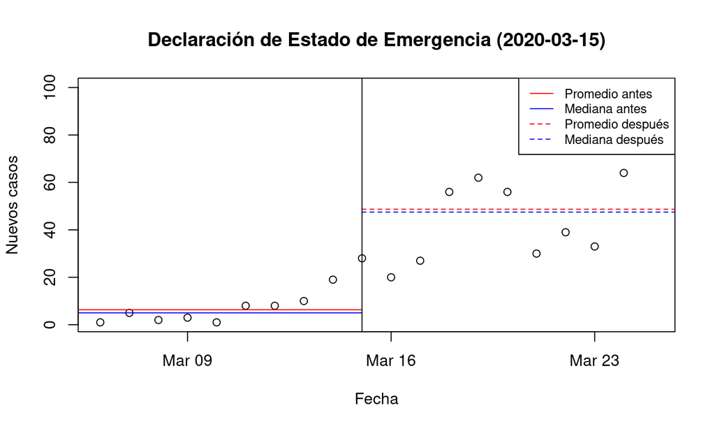

.

## Movilización recreacional 03-05 -> 03-25

```
plot_rmoves("2020-03-05", "2020-03-25")
```

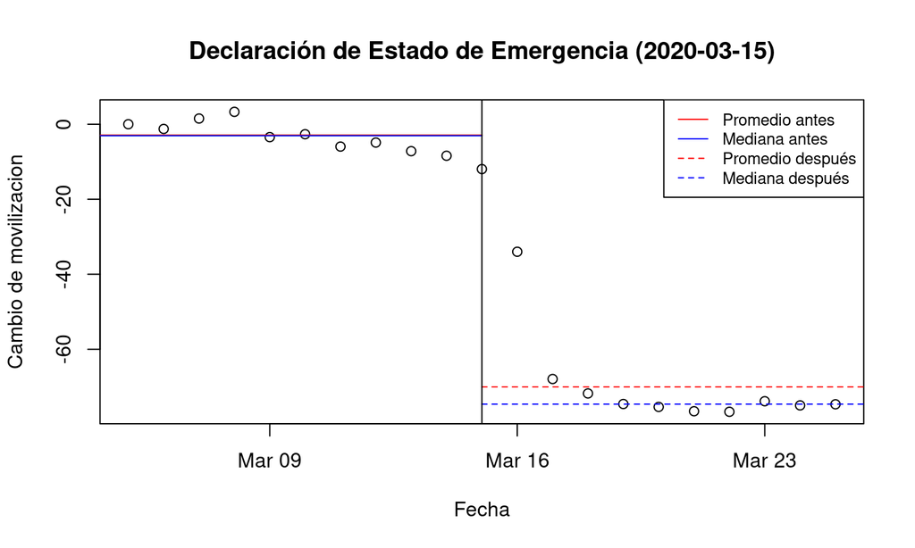

.

## Nuevos casos 03-08 -> 03-28

```
plot_new_cases("2020-03-08", "2020-03-28")
```

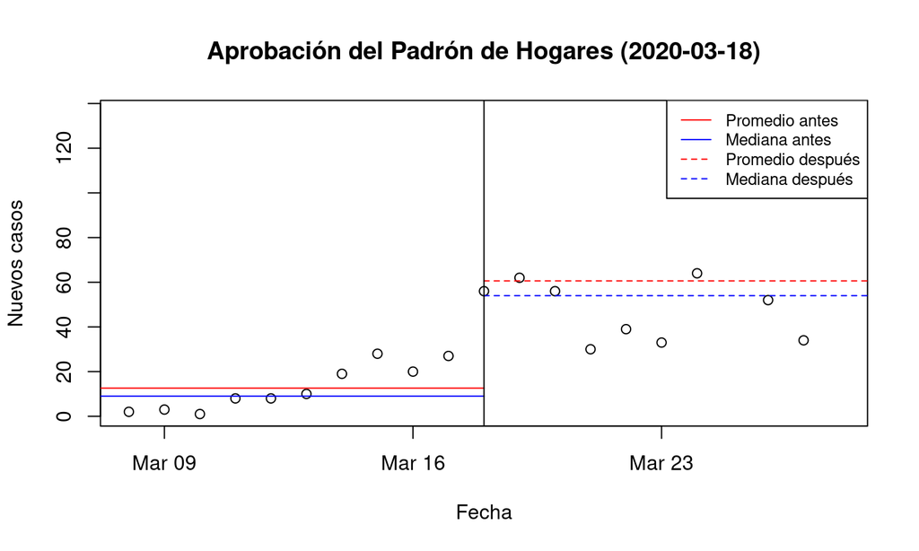

.

## Movilización recreacional 03-08 -> 03-28

```
plot_rmoves("2020-03-08", "2020-03-28")
```

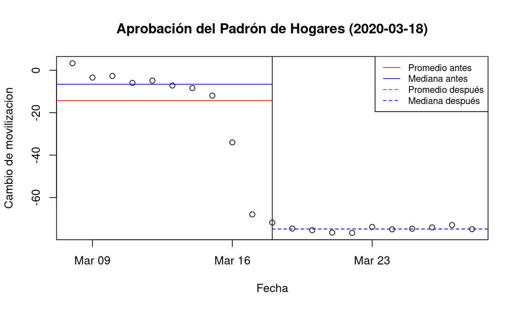

.

## Nuevos casos 03-24 -> 04-13

```
plot_new_cases("2020-03-24", "2020-04-13")
```

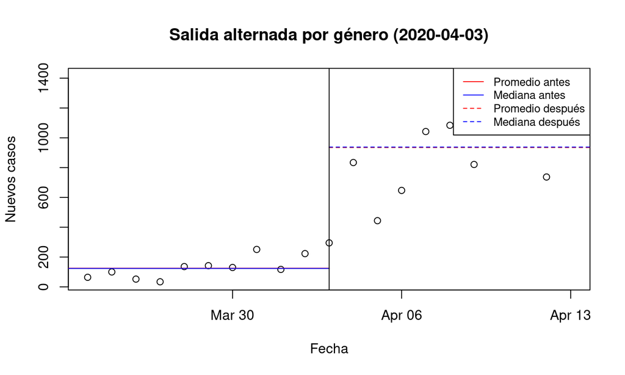

.

## Movilización recreacional 03-24 -> 04-13

```
plot_rmoves("2020-03-24", "2020-04-13")
```

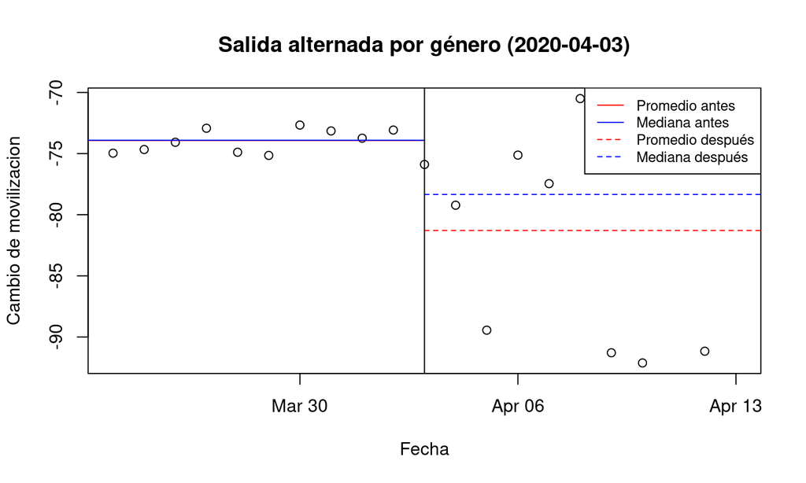

.

## Nuevos casos 04-10 -> 04-30

```
plot_new_cases("2020-04-10", "2020-04-30")
```

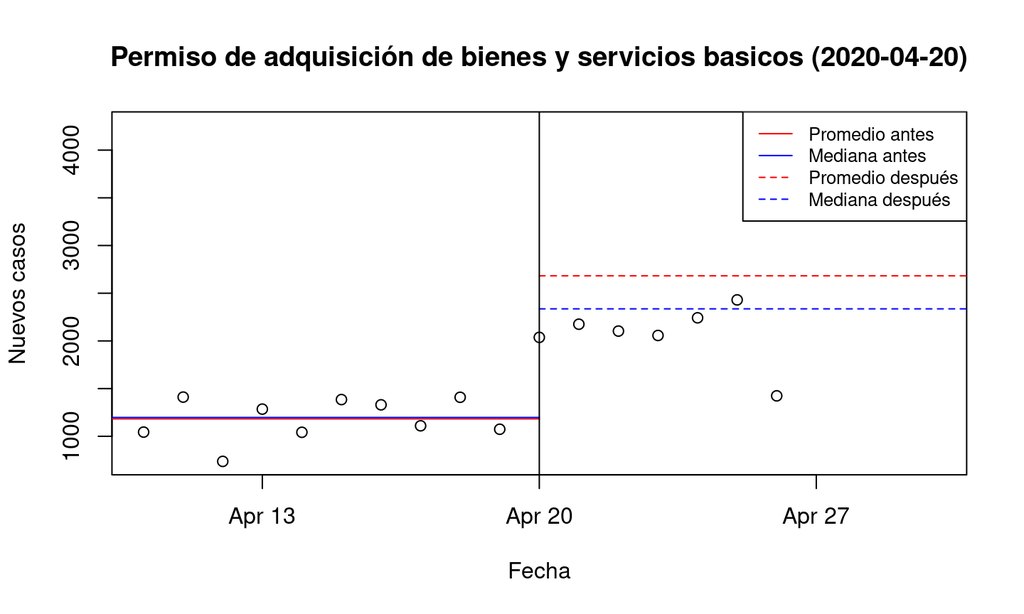

.

## Movilización recreacional 04-10 -> 04-30

```
plot_rmoves("2020-04-10", "2020-04-30")
```

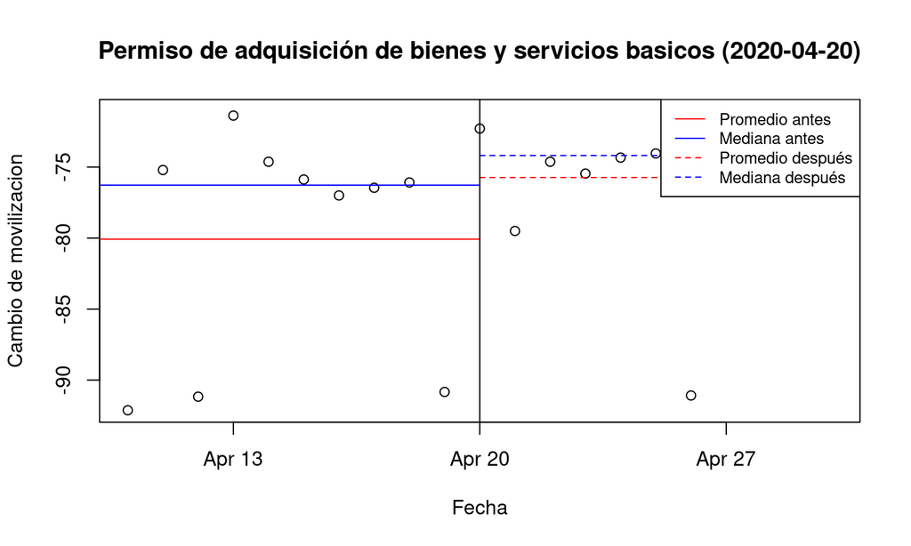

.

## Conclusiones/hipótesis

En base a los datos que ya tenemos y hemos procesado pensamos existe una relación clara entre las medidas tomadas y la cantidad de infectados, ya que las graficas varian de una u otra manera entre los días anteriores a tomar cada medida y los posteriores. Además, pensamos que todas las medidas escogidas afectaron la cantidad de infectados por día de manera similar, debido a que los gráficos muestran un cambio parecido dias despues de que se aplicara cada medida.

## Extra

1. Con la encuesta se han obtenido datos que se nos hace difícil de manejar. Por ejemplo, en uno de los descriptores se le pregunta a la persona por las medidas que ellos recuerdan para luego incluirlo en el análisis de impacto y correlacionarlos con la data.
2. Se ha optado por incluir variables como “Justificaciones de salida”. “tiempo”, ”medidas”.
3. Asimismo, se están incluyendo preguntas exploratorias y descriptivas tales como, “¿Por qué razones sales durante la cuarentena?” o “Qué tanto consideras que tu distrito se ha visto afectado?”